# Part II - Effects of Age, User Type and Gender on the Trip Duration

## by Chukwudi Chidubem

## Investigation Overview

> In this investigation, I am looking at the features in the dataset that can be used to predict the Trip duration. The main focus is on the Age, User Type and the Gender.

## Dataset Overview

> The dataset was made up of 183412 rows representing the number of trips and 16 columns representing variables but after some data wrangling was applied the data is now made up of 174952 rows and 16 columns. Also, the dataypes of some columns have been changed and some feature engineering has been applied to the dataset.

## Distribution of Trip Duration

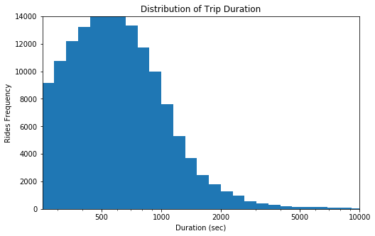

## Distribution of Age of the Users

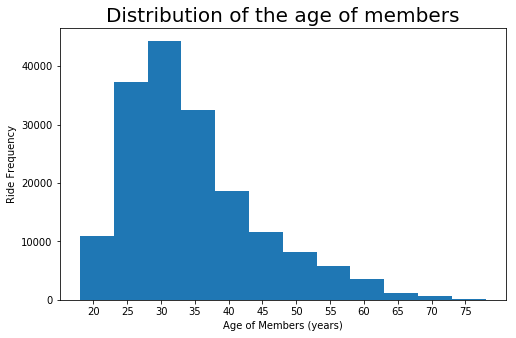

## Trip Duration vs User Type

Plotting the relationship using both a bar plot and a logarithmic transformed box plot produces a linear relationship. It is seen that Customers spend more time with the bikes than subscribers. Also there are alot of outliers for trips longer than 3000 seconds.

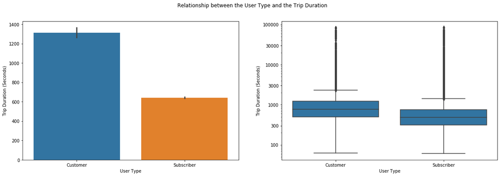

## Trip Duration vs Gender

plotting the relationship using simply a barplot. it can be observed that the **Other** gender spend the most time with the bikes, with **Male** gender spending the least time.

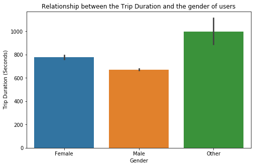